# Project 5 - FMT

## Author - [Shekar Roy](https://github.com/shekarroy15)

### DOMAIN: Semiconductor manufacturing process

##### CONTEXT: A complex modern semiconductor manufacturing process is normally under constant surveillance via the monitoring of signals/variables collected from sensors and or process measurement points. However, not all of these signals are equally valuable in a specific monitoring system. The measured signals contain a combination of useful information, irrelevant information as well as noise. Engineers typically have a much larger number of signals than are actually required. If we consider each type of signal as a feature, then feature selection may be applied to identify the most relevant signals. The Process Engineers may then use these signals to determine key factors contributing to yield excursions downstream in the process. This will enable an increase in process throughput, decreased time to learning and reduce the per unit production costs. These signals can be used as features to predict the yield type. And by analysing and trying out different combinations of features, essential signals that are impacting the yield type can be identified.

```python
import numpy as np
import pandas as pd
import matplotlib.pyplot as plt
import seaborn as sns
import warnings
warnings.filterwarnings("ignore")

from sklearn.model_selection import train_test_split
from sklearn.model_selection import learning_curve
from sklearn.preprocessing import StandardScaler
from sklearn.metrics import confusion_matrix
from sklearn.metrics import average_precision_score
from sklearn.metrics import precision_recall_curve

from sklearn.ensemble import RandomForestClassifier
from sklearn.tree import DecisionTreeClassifier
from sklearn.svm import SVC
from sklearn.naive_bayes import GaussianNB
from sklearn.ensemble import AdaBoostClassifier
from sklearn.ensemble import GradientBoostingClassifier
import xgboost as xgb
from xgboost.sklearn import XGBClassifier
from sklearn.neighbors import KNeighborsClassifier

from imblearn.over_sampling import SMOTE

from sklearn.model_selection import GridSearchCV
from sklearn.decomposition import PCA

import pickle
```

```python
data = pd.read_csv('signal-data.csv')
```

```python
data.sample(5)
```

|  | Time | 0 | 1 | 2 | 3 | 4 | 5 | 6 | 7 | 8 | ... | 581 | 582 | 583 | 584 | 585 | 586 | 587 | 588 | 589 | Pass/Fail |
| --- | --- | --- | --- | --- | --- | --- | --- | --- | --- | --- | --- | --- | --- | --- | --- | --- | --- | --- | --- | --- | --- |
| 1001 | 2008-09-22 00:28:00 | 3022.60 | 2533.92 | 2184.7222 | 1009.0221 | 1.3187 | 100.0 | 101.9178 | 0.1219 | 1.4772 | ... | NaN | 0.5012 | 0.0153 | 0.0038 | 3.0516 | 0.0096 | 0.0191 | 0.0069 | 197.5077 | -1 |
| 1057 | 2008-09-24 10:59:00 | 3005.31 | 2409.49 | 2200.2000 | 1121.1875 | 1.3171 | 100.0 | 103.8978 | 0.1191 | 1.4649 | ... | NaN | 0.4980 | 0.0118 | 0.0033 | 2.3639 | 0.0090 | 0.0166 | 0.0047 | 183.3928 | -1 |
| 656 | 2008-02-09 03:33:00 | 2992.39 | 2591.83 | 2233.1556 | 1434.9983 | 1.5188 | 100.0 | 102.6611 | 0.1235 | 1.3969 | ... | NaN | 0.5052 | 0.0123 | 0.0036 | 2.4259 | 0.0140 | 0.0112 | 0.0038 | 80.4663 | -1 |
| 608 | 2008-08-31 15:09:00 | 3065.45 | 2698.14 | 2200.0666 | 1012.6747 | 1.3954 | 100.0 | 103.0644 | 0.1212 | 1.4522 | ... | 62.3881 | 0.4982 | 0.0194 | 0.0043 | 3.8846 | 0.0252 | 0.0157 | 0.0046 | 62.3881 | -1 |
| 667 | 2008-02-09 07:32:00 | 2938.11 | 2471.74 | 2233.1556 | 1434.9983 | 1.5188 | 100.0 | 102.6611 | 0.1235 | 1.4890 | ... | NaN | 0.5006 | 0.0216 | 0.0046 | 4.3178 | 0.0263 | 0.0117 | 0.0033 | 44.3686 | -1 |

5 rows × 592 columns

```python
data.columns
```

```
Index(['Time', '0', '1', '2', '3', '4', '5', '6', '7', '8',
       ...
       '581', '582', '583', '584', '585', '586', '587', '588', '589',
       'Pass/Fail'],
      dtype='object', length=592)
```

```python
data.info()
```

```
<class 'pandas.core.frame.DataFrame'>
RangeIndex: 1567 entries, 0 to 1566
Columns: 592 entries, Time to Pass/Fail
dtypes: float64(590), int64(1), object(1)
memory usage: 7.1+ MB
```

```python
data.describe().T
```

|  | count | mean | std | min | 25% | 50% | 75% | max |
| --- | --- | --- | --- | --- | --- | --- | --- | --- |
| 0 | 1561.0 | 3014.452896 | 73.621787 | 2743.2400 | 2966.260000 | 3011.4900 | 3056.6500 | 3356.3500 |
| 1 | 1560.0 | 2495.850231 | 80.407705 | 2158.7500 | 2452.247500 | 2499.4050 | 2538.8225 | 2846.4400 |
| 2 | 1553.0 | 2200.547318 | 29.513152 | 2060.6600 | 2181.044400 | 2201.0667 | 2218.0555 | 2315.2667 |
| 3 | 1553.0 | 1396.376627 | 441.691640 | 0.0000 | 1081.875800 | 1285.2144 | 1591.2235 | 3715.0417 |
| 4 | 1553.0 | 4.197013 | 56.355540 | 0.6815 | 1.017700 | 1.3168 | 1.5257 | 1114.5366 |
| ... | ... | ... | ... | ... | ... | ... | ... | ... |
| 586 | 1566.0 | 0.021458 | 0.012358 | -0.0169 | 0.013425 | 0.0205 | 0.0276 | 0.1028 |
| 587 | 1566.0 | 0.016475 | 0.008808 | 0.0032 | 0.010600 | 0.0148 | 0.0203 | 0.0799 |
| 588 | 1566.0 | 0.005283 | 0.002867 | 0.0010 | 0.003300 | 0.0046 | 0.0064 | 0.0286 |
| 589 | 1566.0 | 99.670066 | 93.891919 | 0.0000 | 44.368600 | 71.9005 | 114.7497 | 737.3048 |
| Pass/Fail | 1567.0 | -0.867262 | 0.498010 | -1.0000 | -1.000000 | -1.0000 | -1.0000 | 1.0000 |

591 rows × 8 columns

```python
data.isnull().any().any()
```

```
True
```

```python
# Replacing all the NaN values with 0 as the values correspond to the test results. since, the values are not present that means the values are not available or calculated so better we not take median or mean and replace them with zeros

data = data.replace(np.NaN, 0)
data.isnull().any().any()
```

```
False
```

##### Data Visualization

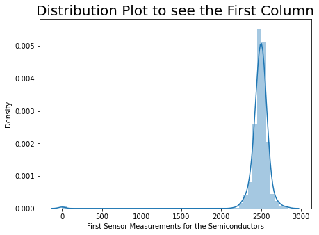

```python
plt.rcParams['figure.figsize'] = (7, 5)
sns.distplot(data['1'])
plt.title('Distribution Plot to see the First Column', fontsize = 20)
plt.xlabel('First Sensor Measurements for the Semiconductors')
plt.show()
```

[figure not shown]

```python
plt.rcParams['figure.figsize'] = (7, 5)
sns.distplot(data['520'])
plt.title('Distribution Plot to see the Last Column', fontsize = 20)
plt.xlabel('First Sensor Measurements for the Semiconductors')
plt.show()
```

```python
data['Pass/Fail'].value_counts()
```

```
-1    1463
 1     104
Name: Pass/Fail, dtype: int64
```

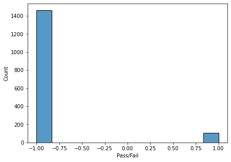

```python
sns.histplot(data = data['Pass/Fail'])
```

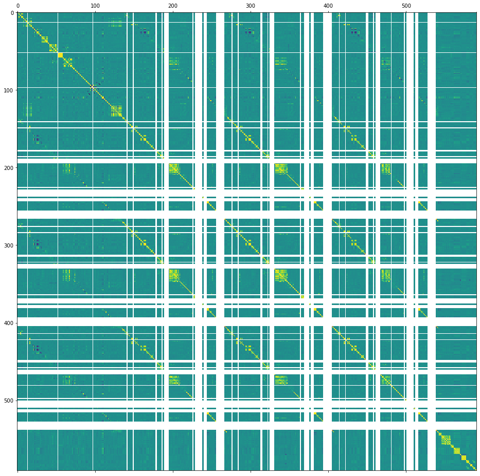

```python
plt.rcParams['figure.figsize'] = (25, 25)
plt.matshow(data.corr());
```

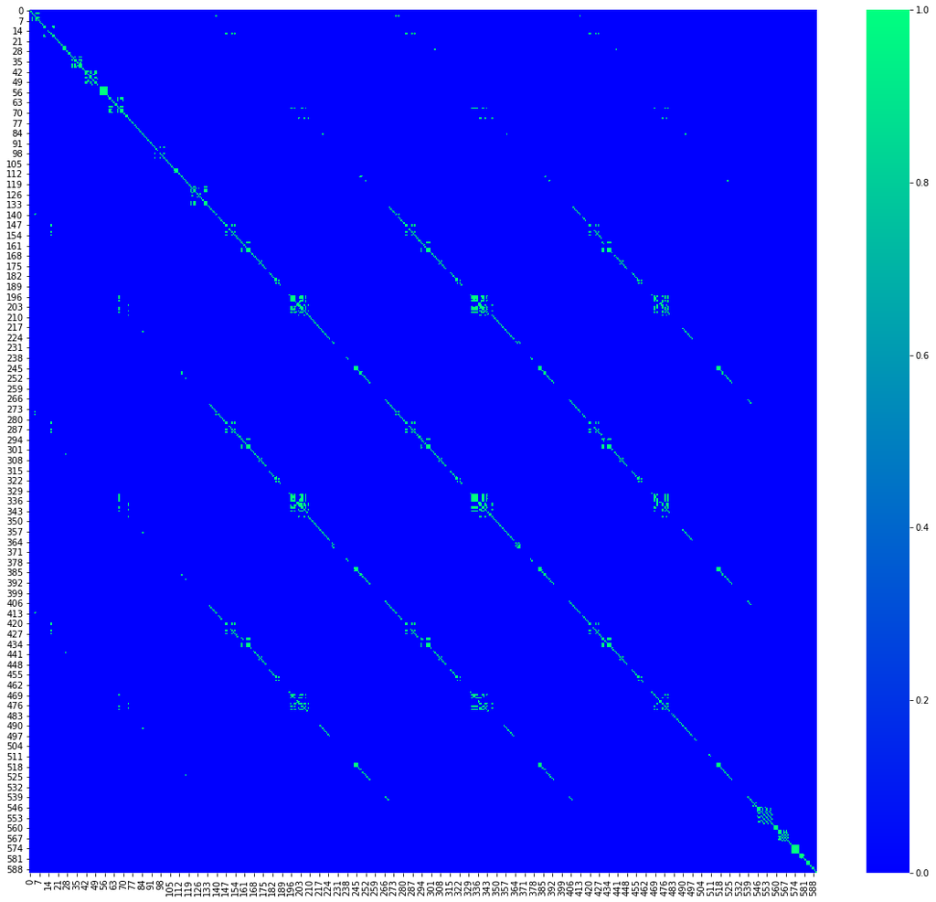

```python
plt.figure(figsize=(20,18))
corr=data.corr()
sns.heatmap(abs(corr>0.7),cmap="winter");
```

```python
# deleting the first column as time has no predictive power here in this case.

data = data.drop(columns = ['Time'], axis = 1)
data.shape
```

```
(1567, 591)
```

```python
# separating the dependent and independent data

x = data.iloc[:,:590]
y = data.iloc[:, 590]

print("shape of x:", x.shape)
print("shape of y:", y.shape)
```

```
shape of x: (1567, 590)
shape of y: (1567,)
```

```python
# test - train split, 80:20

x_train, x_test, y_train, y_test = train_test_split(x, y, test_size = 0.2, random_state = 0)

print("shape of x_train: ", x_train.shape)
print("shape of x_test: ", x_test.shape)
print("shape of y_train: ", y_train.shape)
print("shape of y_test: ", y_test.shape)
```

```
shape of x_train:  (1253, 590)
shape of x_test:  (314, 590)
shape of y_train:  (1253,)
shape of y_test:  (314,)
```

```python
sc = StandardScaler()
x_train = sc.fit_transform(x_train)
x_test = sc.transform(x_test)
```